title: “HW2” author: “William Florez” date: “31 de mayo de 2017” github: https://github.com/wiflore output: html_document: default word_document: default —

## HW2

### Question 1

A clustering problem for could be *Fixed Income - Treasuries Asset Allocation*

**The possible outcome could be:**

1. Long run bonds looks better vs Short Term bonds
2. Short run bonds looks better vs Long Term bonds
3. Long run bonds looks and Short Term bonds looks good
4. Long run bonds looks and Short Term bonds looks bad

**As a predictors I could use:**  
CPI actual  
CPI Forecast  
Central Bank Rate actual  
Central Bank Forecast  
GDP actual  
GDP Forecast  
Consumer Sentiment  
Private Payrolls  
Dividend Yield vs Corporate Bond Yield  
US vs German bonds yield spread  
Leading indicators  
US 2year vs US 10year yield spread

### Question 2

```r
library(gplots)
library(datasets)
library(ggplot2)

set.seed(123)

data <- iris
head(data)
```

```
##   Sepal.Length Sepal.Width Petal.Length Petal.Width Species
## 1          5.1         3.5          1.4         0.2  setosa
## 2          4.9         3.0          1.4         0.2  setosa
## 3          4.7         3.2          1.3         0.2  setosa
## 4          4.6         3.1          1.5         0.2  setosa
## 5          5.0         3.6          1.4         0.2  setosa
## 6          5.4         3.9          1.7         0.4  setosa
```

```r
x = data[,-5]
y = data$Species

kcx <- kmeans(x, 3, nstart = 20)
kcx
```

```
## K-means clustering with 3 clusters of sizes 50, 38, 62
##
## Cluster means:
##   Sepal.Length Sepal.Width Petal.Length Petal.Width
## 1     5.006000    3.428000     1.462000    0.246000
## 2     6.850000    3.073684     5.742105    2.071053
## 3     5.901613    2.748387     4.393548    1.433871
##
## Clustering vector:
##   [1] 1 1 1 1 1 1 1 1 1 1 1 1 1 1 1 1 1 1 1 1 1 1 1 1 1 1 1 1 1 1 1 1 1 1 1
##  [36] 1 1 1 1 1 1 1 1 1 1 1 1 1 1 1 3 3 2 3 3 3 3 3 3 3 3 3 3 3 3 3 3 3 3 3
##  [71] 3 3 3 3 3 3 3 2 3 3 3 3 3 3 3 3 3 3 3 3 3 3 3 3 3 3 3 3 3 3 2 3 2 2 2
## [106] 2 3 2 2 2 2 2 2 3 3 2 2 2 2 3 2 3 2 3 2 2 3 3 2 2 2 2 2 3 2 2 2 2 3 2
## [141] 2 2 3 2 2 2 3 2 2 3
##
## Within cluster sum of squares by cluster:
## [1] 15.15100 23.87947 39.82097
##  (between_SS / total_SS =  88.4 %)
##
## Available components:
##
## [1] "cluster"      "centers"      "totss"        "withinss"
## [5] "tot.withinss" "betweenss"    "size"         "iter"
## [9] "ifault"
```

```r
#Check correlation for looking improvements
cor(x)
```

```
##              Sepal.Length Sepal.Width Petal.Length Petal.Width
## Sepal.Length    1.0000000  -0.1175698    0.8717538   0.8179411
## Sepal.Width    -0.1175698   1.0000000   -0.4284401  -0.3661259
## Petal.Length    0.8717538  -0.4284401    1.0000000   0.9628654
## Petal.Width     0.8179411  -0.3661259    0.9628654   1.0000000
```

```r
#Sepal.Width very uncorrelated variable
#Rerunning without Sepal.width
z = x[,-2]
kcz <- kmeans(z, 3, nstart = 20)
kcz
```

```
## K-means clustering with 3 clusters of sizes 38, 50, 62
##
## Cluster means:
##   Sepal.Length Petal.Length Petal.Width
## 1     6.850000     5.742105    2.071053
## 2     5.006000     1.462000    0.246000
## 3     5.901613     4.393548    1.433871
##
## Clustering vector:
##   [1] 2 2 2 2 2 2 2 2 2 2 2 2 2 2 2 2 2 2 2 2 2 2 2 2 2 2 2 2 2 2 2 2 2 2 2
##  [36] 2 2 2 2 2 2 2 2 2 2 2 2 2 2 2 3 3 1 3 3 3 3 3 3 3 3 3 3 3 3 3 3 3 3 3
##  [71] 3 3 3 3 3 3 3 1 3 3 3 3 3 3 3 3 3 3 3 3 3 3 3 3 3 3 3 3 3 3 1 3 1 1 1
## [106] 1 3 1 1 1 1 1 1 3 3 1 1 1 1 3 1 3 1 3 1 1 3 3 1 1 1 1 1 3 1 1 1 1 3 1
## [141] 1 1 3 1 1 1 3 1 1 3
##
## Within cluster sum of squares by cluster:
## [1] 20.76579  8.11020 34.46613
##  (between_SS / total_SS =  90.3 %)
##
## Available components:
##
## [1] "cluster"      "centers"      "totss"        "withinss"
## [5] "tot.withinss" "betweenss"    "size"         "iter"
## [9] "ifault"
```

```r
#Comparing Results
table(y,kcx$cluster)
```

```
##
## y             1  2  3
##   setosa     50  0  0
##   versicolor  0  2 48
##   virginica   0 36 14
```

```r
table(y,kcz$cluster)
```

```
##
## y             1  2  3
##   setosa      0 50  0
##   versicolor  2  0 48
##   virginica  36  0 14
```

```r
#Nothing Improve. So I will test with the most correlated variables Petal.Lengh and Petal.Width
w = z[,-1]
kcw <- kmeans(w, 3, nstart = 20)
kcw
```

```
## K-means clustering with 3 clusters of sizes 50, 52, 48
##
## Cluster means:
##   Petal.Length Petal.Width
## 1     1.462000    0.246000
## 2     4.269231    1.342308
## 3     5.595833    2.037500
##
## Clustering vector:
##   [1] 1 1 1 1 1 1 1 1 1 1 1 1 1 1 1 1 1 1 1 1 1 1 1 1 1 1 1 1 1 1 1 1 1 1 1
##  [36] 1 1 1 1 1 1 1 1 1 1 1 1 1 1 1 2 2 2 2 2 2 2 2 2 2 2 2 2 2 2 2 2 2 2 2
##  [71] 2 2 2 2 2 2 2 3 2 2 2 2 2 3 2 2 2 2 2 2 2 2 2 2 2 2 2 2 2 2 3 3 3 3 3
## [106] 3 2 3 3 3 3 3 3 3 3 3 3 3 3 2 3 3 3 3 3 3 2 3 3 3 3 3 3 3 3 3 3 3 2 3
## [141] 3 3 3 3 3 3 3 3 3 3
##
## Within cluster sum of squares by cluster:
## [1]  2.02200 13.05769 16.29167
##  (between_SS / total_SS =  94.3 %)
##
## Available components:
##
## [1] "cluster"      "centers"      "totss"        "withinss"
## [5] "tot.withinss" "betweenss"    "size"         "iter"
## [9] "ifault"
```

```r
table(y,kcz$cluster)
```

```
##
## y             1  2  3
##   setosa      0 50  0
##   versicolor  2  0 48
##   virginica  36  0 14
```

```r
table(y,kcw$cluster)
```

```
##
## y             1  2  3
##   setosa     50  0  0
##   versicolor  0 48  2
##   virginica   0  4 46
```

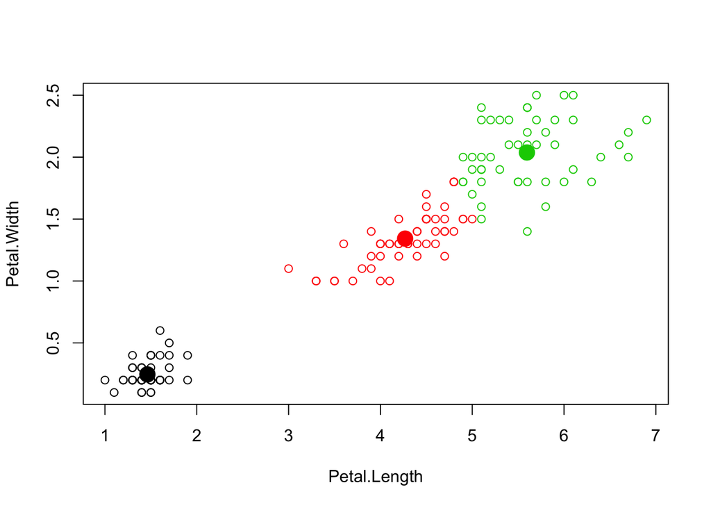

```r
#That looks better

#Ploting
plot(x[c("Petal.Length", "Petal.Width")], col=kcw$cluster)
points(kcw$centers[,c("Petal.Length", "Petal.Width")], col=1:3, pch=20, cex=3)
```

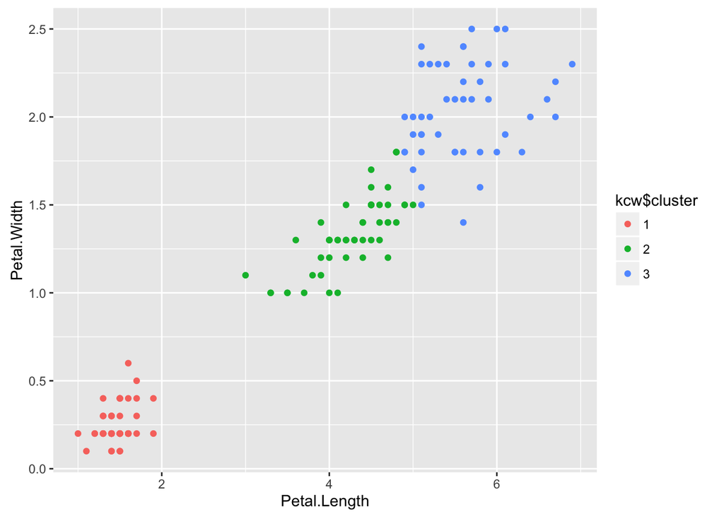

```r
kcw$cluster <- as.factor(kcw$cluster)
ggplot(data, aes(Petal.Length, Petal.Width, color = kcw$cluster)) + geom_point()
```

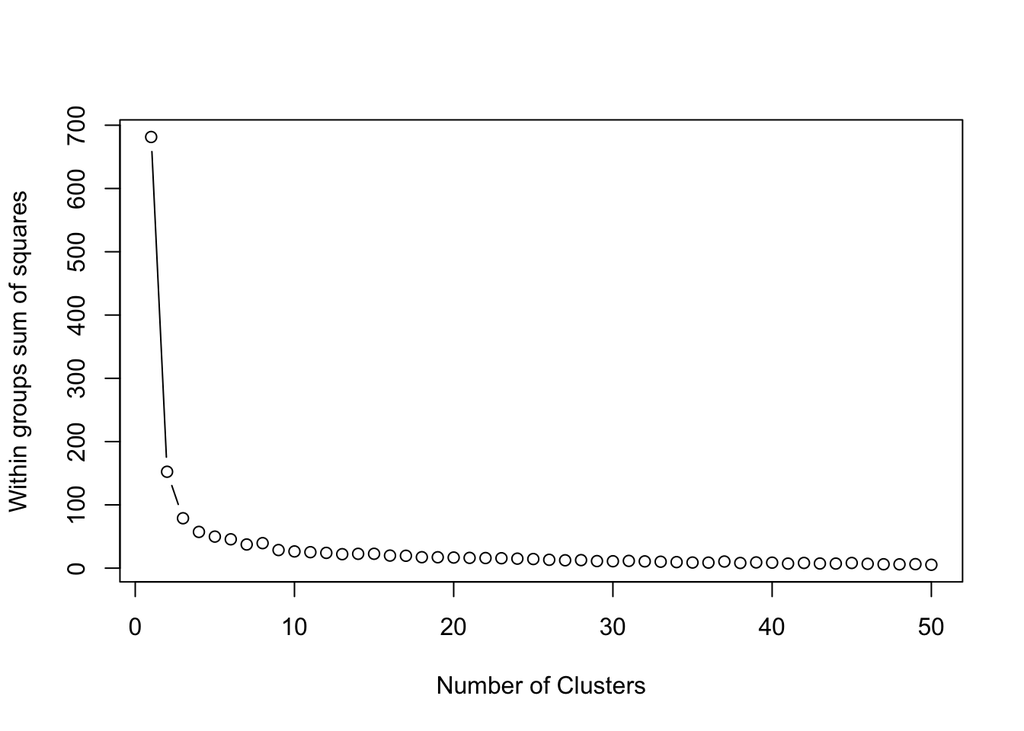

```r
#Is this were a unsupervised problem the best way to determine the K is looking the sum of squares

wss = NULL
##Looking best k for unsupervised problem
for (i in 1:50) wss[i] <- sum(kmeans(x,
                                     centers = i)$withinss)
plot(1:50, wss, type = "b", xlab = "Number of Clusters",
     ylab = "Within groups sum of squares")
```

```r
#Clustering with K = 20
kc <- kmeans(x,20)
kc
```

```
## K-means clustering with 20 clusters of sizes 16, 9, 6, 1, 7, 6, 7, 5, 9, 4, 10, 9, 7, 6, 12, 3, 8, 8, 7, 10
##
## Cluster means:
##    Sepal.Length Sepal.Width Petal.Length Petal.Width
## 1      4.668750    3.025000     1.412500   0.1937500
## 2      4.877778    3.444444     1.355556   0.2111111
## 3      6.216667    2.650000     4.366667   1.3166667
## 4      4.900000    2.500000     4.500000   1.7000000
## 5      5.528571    4.042857     1.471429   0.2857143
## 6      7.716667    3.166667     6.566667   2.1500000
## 7      6.785714    3.242857     5.785714   2.3285714
## 8      7.240000    2.980000     6.020000   1.8400000
## 9      6.722222    3.000000     4.677778   1.4555556
## 10     5.000000    2.300000     3.275000   1.0250000
## 11     5.270000    3.500000     1.470000   0.2300000
```

[output cut: 30 more lines]

```r
table(y,kc$cluster)
```

```
##
## y             1  2  3  4  5  6  7  8  9 10 11 12 13 14 15 16 17 18 19 20
##   setosa     16  9  0  0  7  0  0  0  0  0 10  0  0  0  0  0  0  8  0  0
##   versicolor  0  0  6  0  0  0  0  0  9  4  0  7  0  0 12  0  0  0  2 10
##   virginica   0  0  0  1  0  6  7  5  0  0  0  2  7  6  0  3  8  0  5  0
```

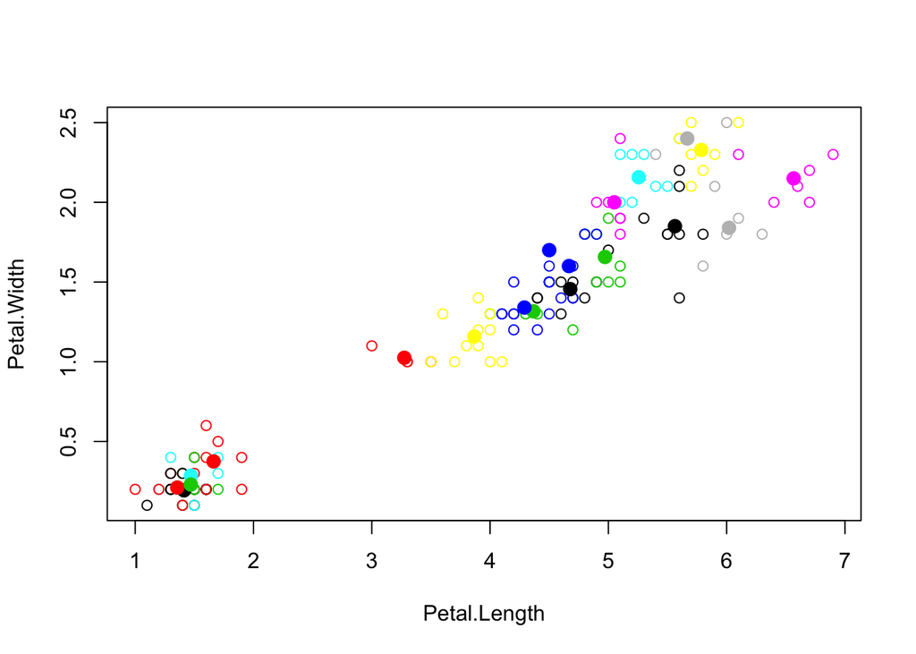

```r
plot(x[c("Petal.Length", "Petal.Width")], col=kc$cluster)
points(kc$centers[,c("Petal.Length", "Petal.Width")], col=1:20, pch=20, cex=2)
```

```r
#This is hard to analyze and looks overfitting
```

To summarize

**The best combination of predictors are:** Petal.Length and Petal.Width

**My suggested value of k** = 3, because we already know there are 3 classes. Evaluating ebow chart a k betweetn 20-30 could reduce error squares but looks overfitting and hard to interpreted

**How well your best clustering predicts flower type:** 96% of accuracy

### Question 3

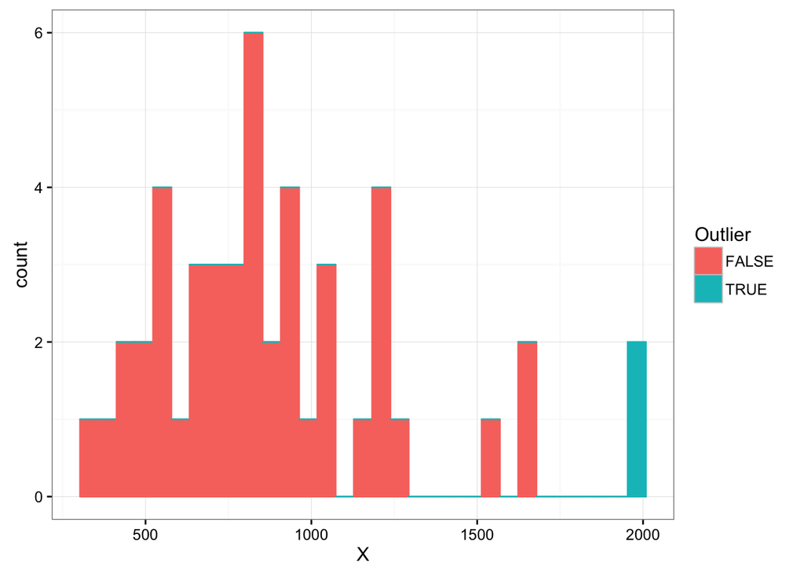

```r
library(outliers)
library(ggplot2)
library(RCurl)
data <- getURL("http://www.statsci.org/data/general/uscrime.txt")
data = read.table(text = data, header = TRUE)

X <- data$Crime
grubbs.flag <- function(x) {
  outliers <- NULL
  test <- x
  grubbs.result <- grubbs.test(test)
  pv <- grubbs.result$p.value
  while(pv < 0.1) {
    outliers <- c(outliers,as.numeric(strsplit(grubbs.result$alternative," ")[[1]][3]))
    test <- x[!x %in% outliers]
    grubbs.result <- grubbs.test(test)
    pv <- grubbs.result$p.value
  }
  return(data.frame(X=x,Outlier=(x %in% outliers)))
}

# Plot the outliers highlighted in colour:

ggplot(grubbs.flag(X),aes(x=X,color=Outlier,fill=Outlier))+
  geom_histogram(binwidth=diff(range(X))/30)+
  theme_bw()
```

```r
grubbs.flag(X)
```

```
##       X Outlier
## 1   791   FALSE
## 2  1635   FALSE
## 3   578   FALSE
## 4  1969    TRUE
## 5  1234   FALSE
## 6   682   FALSE
## 7   963   FALSE
## 8  1555   FALSE
## 9   856   FALSE
## 10  705   FALSE
## 11 1674   FALSE
## 12  849   FALSE
## 13  511   FALSE
## 14  664   FALSE
```

[output cut: 33 more lines]

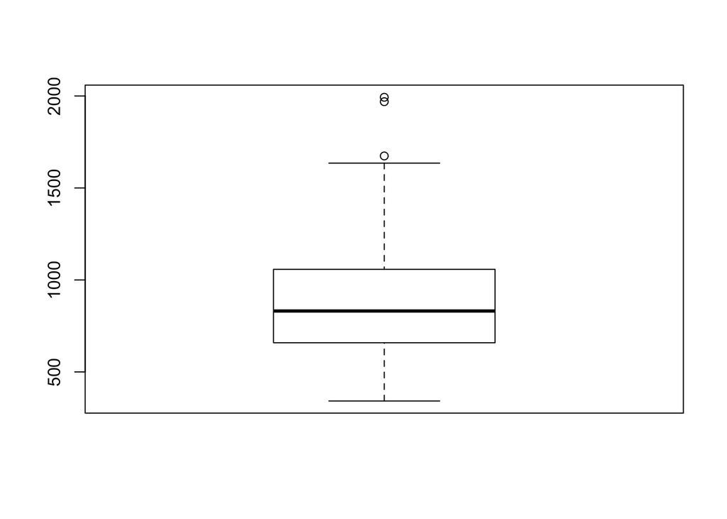

```r
d = density(X)
boxplot(X)
```

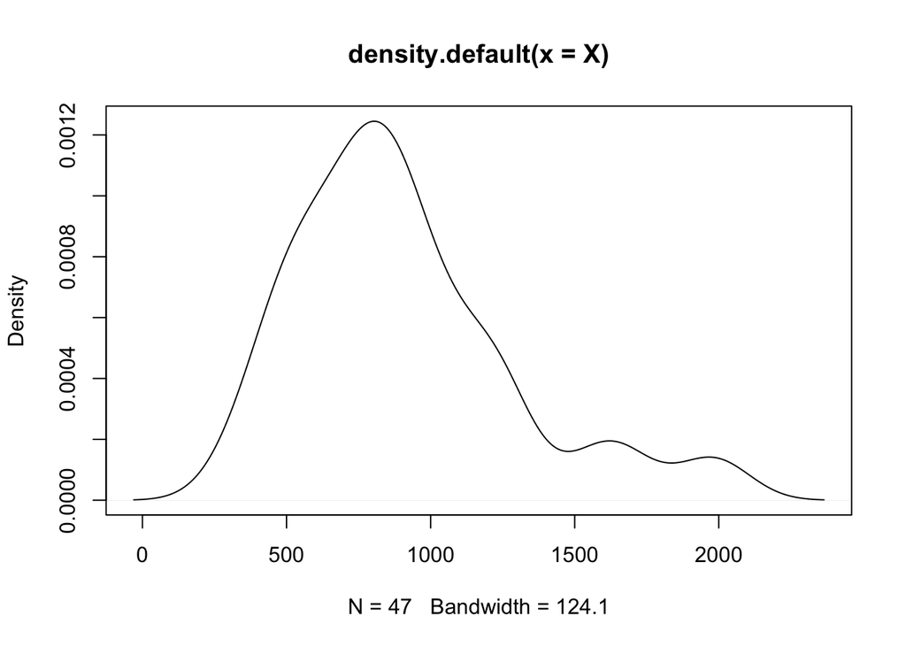

```r
plot(d)
```

```r
boxplot.stats(X)$out
```

```
## [1] 1969 1674 1993
```

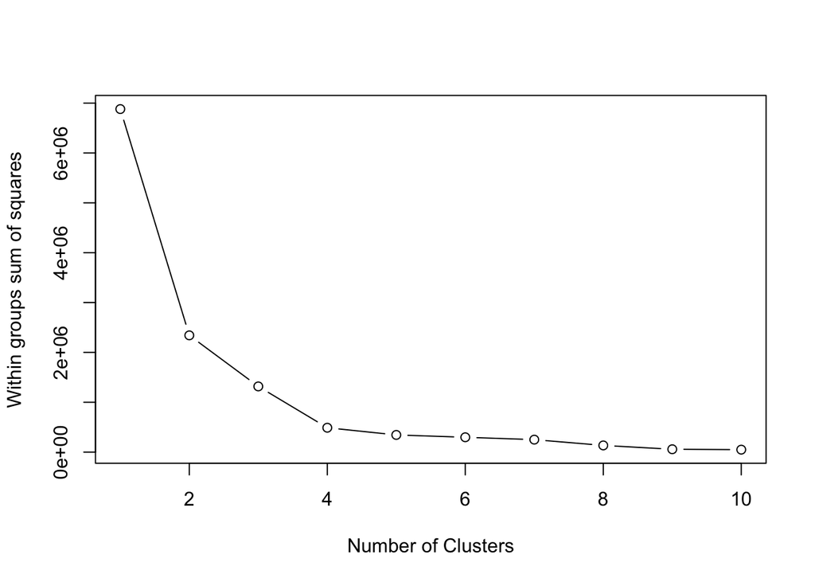

```r
#The initial conclusion is that highest-crime is a outlier with a cofident of
#let see clustering for better understading

wss = NULL
##Looking best k for unsupervised problem
for (i in 1:10) wss[i] <- sum(kmeans(X,
                                     centers = i)$withinss)
plot(1:10, wss, type = "b", xlab = "Number of Clusters",
     ylab = "Within groups sum of squares")
```

```r
#ebow chart suggets k = 4 so let cluster the data

k = 4
kc = kmeans(X, centers = k)
kc
```

```
## K-means clustering with 4 clusters of sizes 13, 20, 5, 9
##
## Cluster means:
##        [,1]
## 1  514.8462
## 2  828.0500
## 3 1765.2000
## 4 1162.1111
##
## Clustering vector:
##  [1] 2 3 1 3 4 2 2 3 2 2 3 2 1 1 2 2 1 2 2 4 2 1 4 2 1 3 1 4 4 2 1 2 4 2 1
## [36] 4 2 1 2 4 2 1 2 4 1 1 2
##
## Within cluster sum of squares by cluster:
## [1] 108717.69 150476.95 162880.80  66890.89
##  (between_SS / total_SS =  92.9 %)
##
## Available components:
##
## [1] "cluster"      "centers"      "totss"        "withinss"
## [5] "tot.withinss" "betweenss"    "size"         "iter"
## [9] "ifault"
```

```r
clusters = kc$cluster
testing = data
testing = data.frame(scale(testing))
testing$Clusters = factor(clusters, levels = 1:k,
                          labels = letters[1:k])
table(clusters)
```

```
## clusters
##  1  2  3  4
## 13 20  5  9
```

```r
aggregate(data, by = list(testing$Clusters),FUN = mean)
```

```
##   Group.1        M        So       Ed       Po1       Po2        LF
## 1       a 13.63077 0.2307692 10.33077  6.384615  6.000000 0.5572308
## 2       b 14.14500 0.5000000 10.40000  8.055000  7.665000 0.5590000
## 3       c 13.30000 0.2000000 11.38000 12.960000 12.080000 0.5826000
## 4       d 13.85556 0.2222222 10.81111 10.066667  9.488889 0.5598889
##         M.F      Pop        NW         U1       U2   Wealth     Ineq
## 1  98.13077 23.76923  7.269231 0.09900000 3.300000 4744.615 19.96923
## 2  98.12500 30.70000 12.995000 0.09415000 3.390000 5235.000 19.60500
## 3 100.24000 64.80000 10.880000 0.09120000 3.720000 6066.000 17.78000
## 4  97.86667 52.66667  7.388889 0.09566667 3.377778 5580.000 19.02222
##         Prob     Time     Crime
## 1 0.05856931 25.08466  514.8462
## 2 0.05083475 25.81493  828.0500
## 3 0.02867960 28.70008 1765.2000
## 4 0.03242233 29.35584 1162.1111
```

```r
#There are not a clusters near to highst data crime
```

### Question 4

I could use CUSUM with the differences of returns between a stock and its peers.  
For example, **the critical value** is the difference of the cummulative return of APPLE vs its peers (AMAZON, GOOGLE, SAMSUNG, ETC) cross some point it point that something it is happening with the company and could be a signal to buy or sell subject to if cross is negative or positive.

### Question 5 - look excel file

[figure not shown]

```r
library(outliers)
library(ggplot2)
library(RCurl)

data <- getURL("https://d37djvu3ytnwxt.cloudfront.net/assets/courseware/v1/592f3be3e90d2bdfe6a69f62374a1250/asset-v1:GTx+ISYE6501x+2T2017+type@asset+block/temps.txt")
data = read.table(text = data, header = TRUE)

plot(data)
```